# script5_WGCNA_HuDis_GBsplit_v1

Shradha Mukherjee

Last updated January, 2019

# Checklist for this pipeline

To reuse this code for other datasets a) replace “HuAgeGBsplit_” for module naming to pre-fix of users choice that is meaningful for the dataset. Here Hu=Human, Age=Age, Dis=Disease b) in this pipeline human gene symbols are used

Continue with WGCNA pipeline

HuAgeGBsplit

### Step13: Load libraries, set working directory and Import data for WGCNA

```r
#If restarting program uncomment line below
#load(file="temp.RData")

#save working directory location
wd<-getwd()
wd
```

```
## [1] "/home/smukherjee/tests/test_April/test73"
```

```r
#Load additional functions required for this pipeline
#Reference: Miller, J.A., Horvath, S., and Geschwind, D.H. (2010). Divergence of Human and mouse brain transcriptome highlights Alzheimer disease pathways. Proceedings of the National Academy of Sciences of the United States of America 107, 12698-12703.

write.geneList <- function(PG, filename, allProbes=0, allGenes=0, probe="g")
{
## These functions write a genelist / probelist to a file of geneNames

## USER inputs
# PG = the probe/gene you want written to a gene list
# allProbes = the list of probe names for the above probes
# allGenes = the list of gene names for the corresponding probes
# filename = the filename (can include folder)
# probe = the default ("g") says PG is a gene and doesn''t need to be converted
#         to a gene.  Otherwise PG is assumed to be a probe and converted

gene = PG
if (probe!="g") {
  gene = probe2Gene(PG,allProbes,allGenes)
}
write(gene,filename,sep="\n")

}

cor.test.l = function(x){
## Performs a Pearson correlation on a vector of genes
 ct = cor.test(x,var)
 return(c(ct$est,ct$p.val))
}
```

```r
#library(BiocInstaller)
#biocLite("qvalue")
#install.packages(c("impute","dynamicTreeCut","flashClust","Hmisc","WGCNA","stringi","enrichR","filesstrings"))
library(impute)
library(dynamicTreeCut)
library(qvalue)
library(flashClust)
library(Hmisc)
library(WGCNA)
library(stringi)
library(stringr)
library(enrichR)#for pathway analysis
library(filesstrings)#for file organization
options(stringsAsFactors = FALSE)
```

```r
#Human Metadata
metadata=read.csv("./merged_expr_metadata/Step5D_result_merge_SRP091303_to_GSE100297_metadata_SampleID.csv", header=T, sep=',')
colnames(metadata)
```

```
##  [1] "X"
##  [2] "Sample_Name"
##  [3] "HuGroup_Name"
##  [4] "Disease"
##  [5] "Age"
##  [6] "Study"
##  [7] "Gender"
##  [8] "Tissue"
##  [9] "Overall_Survival"
## [10] "Censor_1dead_0alive"
## [11] "Histology"
## [12] "TCGA_subtype"
## [13] "Epi_0notherapy_1therapy_NAnodata"
## [14] "Radio_0notherapy_1therapy_NAnodata"
## [15] "Chemo_0notherapy_1therapy_NAnodata"
## [16] "Epilepsytherapy"
## [17] "Chemoradiotherapy_description"
## [18] "history"
## [19] "Resection"
```

```r
#Order of metadata variable selection in WGCNA same as mod and then remaining variables
#keep only variable we need
metadata_1=metadata[,c("Study","Gender","Disease","Age","Tissue")]
#metadata_1=metadata[,4:8]
rownames(metadata_1)=metadata$Sample_Name
pheno=metadata_1
DT::datatable(metadata)
```

|  | X | Sample_Name | HuGroup_Name | Disease | Age | Study | Gender | Tissue | Overall_Survival | Censor_1dead_0alive | Histology | TCGA_subtype | Epi_0notherapy_1therapy_NAnodata | Radio_0notherapy_1therapy_NAnodata | Chemo_0notherapy_1therapy_NAnodata | Epilepsytherapy | Chemoradiotherapy_description | history | Resection |
| --- | --- | --- | --- | --- | --- | --- | --- | --- | --- | --- | --- | --- | --- | --- | --- | --- | --- | --- | --- |
| 1 | 305 | F_18_Grade_3_SRR934971 | CGGA_D44 | Grade_3 | 18 | SRP027383 | F | brain_tumor | 313 | 1 | AOA | Classical | 0 | 1 | 0 | No therapy | Radiotherapy alone | anaplastic oligodendroastrocytomas | Total resection |
| 2 | 309 | F_18_Grade_3_SRR934975 | CGGA_D48 | Grade_3 | 18 | SRP027383 | F | brain_tumor | 221 | 1 | rAOA | Proneural | 1 | 0 | 1 | Anti-epileptic | Radiotherapy plus with unknown drug | recurrent anaplastic oligodendroastrocytomas | No data |
| 3 | 218 | F_21_Grade_2_SRR934805 | CGGA_685 | Grade_2 | 21 | SRP027383 | F | brain_tumor | 1825 | 0 | A | Proneural | 1 | 1 | 0 | Anti-epileptic | Radiotherapy alone | astrocytomas | Total resection |
| 4 | 212 | F_23_Grade_2_SRR934799 | CGGA_675 | Grade_2 | 23 | SRP027383 | F | brain_tumor | 1835 | 0 | OA | Proneural | 0 | 1 | 0 | No therapy | Radiotherapy alone | oligodendroastrocytomas | Total resection |
| 5 | 121 | F_24_Grade_4_SRR934944 | CGGA_1409 | Grade_4 | 24 | SRP027383 | F | brain_tumor |  |  | GBM | Proneural | 0 | 0 | 0 | No therapy | No therapy | primary Glioblastomas | No data |
| 6 | 135 | F_25_Grade_2_SRR934724 | CGGA_252 | Grade_2 | 25 | SRP027383 | F | brain_tumor | 165 | 0 | A | Proneural | 0 | 1 | 0 | No therapy | Radiotherapy alone | astrocytomas | No data |
| 7 | 303 | F_25_Grade_2_SRR934968 | CGGA_D39 | Grade_2 | 25 | SRP027383 | F | brain_tumor | 355 | 0 | rA | Proneural |  |  |  | No data | No data for chemoradiotherapy | recurrent astrocytomas | No data |
| 8 | 222 | F_25_Grade_4_SRR934809 | CGGA_700 | Grade_4 | 25 | SRP027383 | F | brain_tumor | 669 | 0 | GBM | Proneural | 0 | 1 | 1 | No therapy | Radiotherapy plus temozolomide | primary Glioblastomas | Total resection |
| 9 | 97 | F_26_Grade_3_SRR934925 | CGGA_1307 | Grade_3 | 26 | SRP027383 | F | brain_tumor | 371 | 0 | AOA | Classical | 0 | 1 | 1 | No therapy | Radiotherapy plus temozolomide | anaplastic oligodendroastrocytomas | Total resection |
| 10 | 99 | F_28_Grade_4_SRR934927 | CGGA_1314 | Grade_4 | 28 | SRP027383 | F | brain_tumor | 172 | 1 | GBM | Classical | 0 | 0 | 0 | No therapy | No therapy | primary Glioblastomas | Total resection |

[output cut: 381 more lines]

```r
DT::datatable(pheno)
```

|  | Study | Gender | Disease | Age | Tissue |
| --- | --- | --- | --- | --- | --- |
| F_18_Grade_3_SRR934971 | SRP027383 | F | Grade_3 | 18 | brain_tumor |
| F_18_Grade_3_SRR934975 | SRP027383 | F | Grade_3 | 18 | brain_tumor |
| F_21_Grade_2_SRR934805 | SRP027383 | F | Grade_2 | 21 | brain_tumor |
| F_23_Grade_2_SRR934799 | SRP027383 | F | Grade_2 | 23 | brain_tumor |
| F_24_Grade_4_SRR934944 | SRP027383 | F | Grade_4 | 24 | brain_tumor |
| F_25_Grade_2_SRR934724 | SRP027383 | F | Grade_2 | 25 | brain_tumor |
| F_25_Grade_2_SRR934968 | SRP027383 | F | Grade_2 | 25 | brain_tumor |
| F_25_Grade_4_SRR934809 | SRP027383 | F | Grade_4 | 25 | brain_tumor |
| F_26_Grade_3_SRR934925 | SRP027383 | F | Grade_3 | 26 | brain_tumor |
| F_28_Grade_4_SRR934927 | SRP027383 | F | Grade_4 | 28 | brain_tumor |

[output cut: 381 more lines]

```r
#Human Metadata coded. this was created in the SVA+limma step
metadata_coded=read.csv("./merged_expr_metadata/Step8_result_merge_SRP091303_to_GSE100297_metadata_SampleID_coded_vsCONonly.csv", header=T, sep=',')
colnames(metadata_coded)
```

```
##  [1] "X"                       "Sample_Name"
##  [3] "DiseaseCON"              "DiseaseGrade_2"
##  [5] "DiseaseGrade_3"          "DiseaseGrade_4"
##  [7] "StudyGSE53697"           "StudyGSE64810"
##  [9] "StudyGSE67333"           "StudySRP027383"
## [11] "StudySRP091303"          "GenderM"
## [13] "Tissuehippocampus"       "Tissueoptic_chiasm"
## [15] "Tissueprefrontal_cortex" "Age"
```

```r
#Order of metadata variable selection in WGCNA same as mod and then remaining variables
#keep only variable we need
metadata_1_coded=metadata_coded[,c("StudySRP027383","StudySRP091303","GenderM","DiseaseCON","DiseaseGrade_2","DiseaseGrade_3","DiseaseGrade_4","Age","Tissueprefrontal_cortex")]
#metadata_1_coded=metadata_coded[,2:48]
rownames(metadata_1_coded)=metadata_coded$X
pheno_coded=metadata_1_coded
DT::datatable(metadata_coded)
```

|  | X | Sample_Name | DiseaseCON | DiseaseGrade_2 | DiseaseGrade_3 | DiseaseGrade_4 | StudyGSE53697 | StudyGSE64810 | StudyGSE67333 | StudySRP027383 | StudySRP091303 | GenderM | Tissuehippocampus | Tissueoptic_chiasm | Tissueprefrontal_cortex | Age |
| --- | --- | --- | --- | --- | --- | --- | --- | --- | --- | --- | --- | --- | --- | --- | --- | --- |
| 1 | 1 | F_18_Grade_3_SRR934971 | 0 |  | 1 |  | 0 | 0 | 0 | 1 | 0 | 0 | 0 | 0 | 0 | 18 |
| 2 | 2 | F_18_Grade_3_SRR934975 | 0 |  | 1 |  | 0 | 0 | 0 | 1 | 0 | 0 | 0 | 0 | 0 | 18 |
| 3 | 3 | F_21_Grade_2_SRR934805 | 0 | 1 |  |  | 0 | 0 | 0 | 1 | 0 | 0 | 0 | 0 | 0 | 21 |
| 4 | 4 | F_23_Grade_2_SRR934799 | 0 | 1 |  |  | 0 | 0 | 0 | 1 | 0 | 0 | 0 | 0 | 0 | 23 |
| 5 | 5 | F_24_Grade_4_SRR934944 | 0 |  |  | 1 | 0 | 0 | 0 | 1 | 0 | 0 | 0 | 0 | 0 | 24 |
| 6 | 6 | F_25_Grade_2_SRR934724 | 0 | 1 |  |  | 0 | 0 | 0 | 1 | 0 | 0 | 0 | 0 | 0 | 25 |
| 7 | 7 | F_25_Grade_2_SRR934968 | 0 | 1 |  |  | 0 | 0 | 0 | 1 | 0 | 0 | 0 | 0 | 0 | 25 |
| 8 | 8 | F_25_Grade_4_SRR934809 | 0 |  |  | 1 | 0 | 0 | 0 | 1 | 0 | 0 | 0 | 0 | 0 | 25 |
| 9 | 9 | F_26_Grade_3_SRR934925 | 0 |  | 1 |  | 0 | 0 | 0 | 1 | 0 | 0 | 0 | 0 | 0 | 26 |
| 10 | 10 | F_28_Grade_4_SRR934927 | 0 |  |  | 1 | 0 | 0 | 0 | 1 | 0 | 0 | 0 | 0 | 0 | 28 |

[output cut: 381 more lines]

```r
DT::datatable(pheno_coded)
```

|  | StudySRP027383 | StudySRP091303 | GenderM | DiseaseCON | DiseaseGrade_2 | DiseaseGrade_3 | DiseaseGrade_4 | Age | Tissueprefrontal_cortex |
| --- | --- | --- | --- | --- | --- | --- | --- | --- | --- |
| 1 | 1 | 0 | 0 | 0 |  | 1 |  | 18 | 0 |
| 2 | 1 | 0 | 0 | 0 |  | 1 |  | 18 | 0 |
| 3 | 1 | 0 | 0 | 0 | 1 |  |  | 21 | 0 |
| 4 | 1 | 0 | 0 | 0 | 1 |  |  | 23 | 0 |
| 5 | 1 | 0 | 0 | 0 |  |  | 1 | 24 | 0 |
| 6 | 1 | 0 | 0 | 0 | 1 |  |  | 25 | 0 |
| 7 | 1 | 0 | 0 | 0 | 1 |  |  | 25 | 0 |
| 8 | 1 | 0 | 0 | 0 |  |  | 1 | 25 | 0 |
| 9 | 1 | 0 | 0 | 0 |  | 1 |  | 26 | 0 |
| 10 | 1 | 0 | 0 | 0 |  |  | 1 | 28 | 0 |

[output cut: 381 more lines]

```r
#Human Expression data normalized by SVA lmY
Expr_GeneHu=read.csv("./SVA_lmY/Step10_result_edata_lmY.csv", header =T, sep=',')
colnames(Expr_GeneHu)
```

```
##   [1] "X"                       "F_18_Grade_3_SRR934971"
##   [3] "F_18_Grade_3_SRR934975"  "F_21_Grade_2_SRR934805"
##   [5] "F_23_Grade_2_SRR934799"  "F_24_Grade_4_SRR934944"
##   [7] "F_25_Grade_2_SRR934724"  "F_25_Grade_2_SRR934968"
##   [9] "F_25_Grade_4_SRR934809"  "F_26_Grade_3_SRR934925"
##  [11] "F_28_Grade_4_SRR934927"  "F_29_Grade_2_SRR934985"
##  [13] "F_30_Grade_2_SRR934786"  "F_30_Grade_3_SRR934886"
##  [15] "F_30_Grade_4_SRR934981"  "F_31_Grade_2_SRR934721"
##  [17] "F_31_Grade_4_SRR4407806" "F_32_Grade_2_SRR934910"
##  [19] "F_33_Grade_2_SRR934758"  "F_33_Grade_2_SRR934870"
##  [21] "F_34_Grade_2_SRR4407834" "F_34_Grade_3_SRR934776"
##  [23] "F_35_Grade_2_SRR934731"  "F_35_Grade_2_SRR934749"
##  [25] "F_35_Grade_3_SRR934817"  "F_35_Grade_3_SRR934904"
##  [27] "F_36_Grade_2_SRR934736"  "F_36_Grade_2_SRR934767"
##  [29] "F_36_Grade_2_SRR934836"  "F_36_Grade_3_SRR934973"
```

[output cut: 181 more lines]

```r
Expr_GeneHu_1=Expr_GeneHu[,-1]
rownames(Expr_GeneHu_1)=Expr_GeneHu$X
Expr_GeneHu_1=Expr_GeneHu_1[complete.cases(Expr_GeneHu_1), ]
edata=Expr_GeneHu_1
DT::datatable(head(Expr_GeneHu))
```

|  | X | F_18_Grade_3_SRR934971 | F_18_Grade_3_SRR934975 | F_21_Grade_2_SRR934805 | F_23_Grade_2_SRR934799 | F_24_Grade_4_SRR934944 | F_25_Grade_2_SRR934724 | F_25_Grade_2_SRR934968 | F_25_Grade_4_SRR934809 | F_26_Grade_3_SRR934925 | F_28_Grade_4_SRR934927 | F_29_Grade_2_SRR934985 | F_30_Grade_2_SRR934786 | F_30_Grade_3_SRR934886 | F_30_Grade_4_SRR934981 | F_31_Grade_2_SRR934721 | F_31_Grade_4_SRR4407806 | F_32_Grade_2_SRR934910 | F_33_Grade_2_SRR934758 | F_33_Grade_2_SRR934870 | F_34_Grade_2_SRR4407834 | F_34_Grade_3_SRR934776 | F_35_Grade_2_SRR934731 | F_35_Grade_2_SRR934749 | F_35_Grade_3_SRR934817 | F_35_Grade_3_SRR934904 | F_36_Grade_2_SRR934736 | F_36_Grade_2_SRR934767 | F_36_Grade_2_SRR934836 | … |
| --- | --- | --- | --- | --- | --- | --- | --- | --- | --- | --- | --- | --- | --- | --- | --- | --- | --- | --- | --- | --- | --- | --- | --- | --- | --- | --- | --- | --- | --- | --- |
| 1 | A1BG | 0.331908722124387 | 0.284416792309899 | 0.133274898644542 | 0.467763244538297 | 0.0964474663859763 | 0.726232102329937 | 0.0576944295537576 | 0.237176787999593 | 0.638522986002957 | 0.884214086524321 | 0.40932340601535 | 0.397723283328606 | 0.449188493456216 | 0.420292503336418 | 0.658638181613912 | 0.019639312114237 | 0.469265346623565 | 0.097240349085593 | 0.354330310959219 | 0.273523626968563 | 0.137450973539485 | 0.638263595773503 | 0.617540127265875 | 0.204740993293885 | 0.903923402913944 | 0.633229385087562 | 0.462787000313553 | 0.521745738136746 | … |
| 2 | A2M | 5.93807677509456 | 6.04963483575979 | 6.48646563105223 | 6.23099339753401 | 5.91594424218008 | 6.35100178376857 | 5.42864702632023 | 5.94010113215279 | 6.4991244463282 | 5.84459486214669 | 6.1780403836248 | 6.02424264498095 | 7.14199873902232 | 7.07054831147889 | 6.41617940644717 | 5.32400706006738 | 6.47239389907489 | 6.05150119853155 | 6.61450088454907 | 6.08124020540602 | 6.16918322395034 | 6.22642234442964 | 6.28974373314043 | 6.14849309317953 | 6.34322433347439 | 6.26622173609159 | 5.97439333879622 | 5.89089072079436 | … |
| 3 | A2M-AS1 | 1.34495940078898 | 1.22082227573745 | 0.447847769935124 | 0.925090966262595 | 0.743567068215192 | 1.37716335821927 | 1.1823445280082 | 0.782691510759671 | 1.18448965437282 | 1.13771137342892 | 1.09215658278283 | 2.05789487404141 | 0.891335494652794 | 1.6790516160715 | 1.27614560507162 | 1.13592904718258 | 1.37509562515607 | 1.77272792523612 | 1.59097160412594 | 1.54677676177957 | 0.658909978196988 | 1.04135939800734 | 0.977235849279881 | 2.65680430564383 | 1.4605296378917 | 1.52390418182056 | 1.11453611026416 | 0.404468901461776 | … |
| 4 | A2ML1 | 0.464341094546149 | 0.432265880132555 | 0.606970933285252 | 0.555807058221036 | 0.926203811017656 | 0.460844775507372 | 0.484414266365045 | 0.51124075775578 | 0.126180255156224 | 0.466221244867656 | 0.17078453973935 | 0.340488463861454 | 0.510291451594431 | 0.450500461074508 | 0.517872706247528 | 0.539719447032778 | 0.600438363886524 | 0.328746070928423 | 0.298275757834602 | 0.233782620795071 | 1.26680676878128 | 0.204577977088872 | 0.400747017142983 | 0.17080477693707 | 0.551497711762255 | 0.278883069765284 | 0.343822140621423 | 0.291292414346108 | … |
| 5 | A2ML1-AS1 | 0.0288604727451625 | 0.0256136831471706 | 0.0378078838392993 | 0.0251070891726912 | 0.0591499670075498 | 0.0204550762265264 | 0.0153372781813259 | 0.0258264714960326 | 0.0335137405116342 | 0.00675494445545451 | 0.0146570854355636 | 0.0576831187245032 | 0.00791182054733275 | 0.0300084472237565 | 0.0208315318767061 | 0.0999224449877544 | 0.0153441961426113 | 0.0398131961806714 | 0.0144852265400568 | 0.012979697919609 | 0.0197932829262991 | 0.0426665109517929 | 0.0291030082510302 | 0.0179765136475202 | 0.0408201836230691 | 0.0172293646517909 | 0.0231476341116482 | 0.0449139414011644 | … |
| 6 | A2MP1 | 0.175838369240782 | 0.0779069398919865 | 0.278614540650355 | 0.244548484303516 | 0.132137330052769 | 0.21020414999081 | 0.492618842105504 | 0.302097546104771 | 0.289327890782833 | 0.13994748235482 | 0.130391474906665 | 0.242684587751919 | 0.304914889221815 | 0.0834624410978596 | 0.371119928926924 | 0.0871667537138838 | 0.488418629622804 | 0.251854381684194 | 0.30379148214034 | 0.339825552936068 | 0.12937573574653 | 0.215822040921349 | 0.382809505194407 | 0.181656815349842 | 0.370952855043206 | 0.222826067079641 | 0.394129529683893 | 0.407791613532791 | … |

```r
DT::datatable(head(edata))
```

|  | F_18_Grade_3_SRR934971 | F_18_Grade_3_SRR934975 | F_21_Grade_2_SRR934805 | F_23_Grade_2_SRR934799 | F_24_Grade_4_SRR934944 | F_25_Grade_2_SRR934724 | F_25_Grade_2_SRR934968 | F_25_Grade_4_SRR934809 | F_26_Grade_3_SRR934925 | F_28_Grade_4_SRR934927 | F_29_Grade_2_SRR934985 | F_30_Grade_2_SRR934786 | F_30_Grade_3_SRR934886 | F_30_Grade_4_SRR934981 | F_31_Grade_2_SRR934721 | F_31_Grade_4_SRR4407806 | F_32_Grade_2_SRR934910 | F_33_Grade_2_SRR934758 | F_33_Grade_2_SRR934870 | F_34_Grade_2_SRR4407834 | F_34_Grade_3_SRR934776 | F_35_Grade_2_SRR934731 | F_35_Grade_2_SRR934749 | F_35_Grade_3_SRR934817 | F_35_Grade_3_SRR934904 | F_36_Grade_2_SRR934736 | F_36_Grade_2_SRR934767 | F_36_Grade_2_SRR934836 | F_36_Grade_3_SRR934973 | … |
| --- | --- | --- | --- | --- | --- | --- | --- | --- | --- | --- | --- | --- | --- | --- | --- | --- | --- | --- | --- | --- | --- | --- | --- | --- | --- | --- | --- | --- | --- | --- |
| A1BG | 0.331908722124387 | 0.284416792309899 | 0.133274898644542 | 0.467763244538297 | 0.0964474663859763 | 0.726232102329937 | 0.0576944295537576 | 0.237176787999593 | 0.638522986002957 | 0.884214086524321 | 0.40932340601535 | 0.397723283328606 | 0.449188493456216 | 0.420292503336418 | 0.658638181613912 | 0.019639312114237 | 0.469265346623565 | 0.097240349085593 | 0.354330310959219 | 0.273523626968563 | 0.137450973539485 | 0.638263595773503 | 0.617540127265875 | 0.204740993293885 | 0.903923402913944 | 0.633229385087562 | 0.462787000313553 | 0.521745738136746 | 0.565713994623542 | … |
| A2M | 5.93807677509456 | 6.04963483575979 | 6.48646563105223 | 6.23099339753401 | 5.91594424218008 | 6.35100178376857 | 5.42864702632023 | 5.94010113215279 | 6.4991244463282 | 5.84459486214669 | 6.1780403836248 | 6.02424264498095 | 7.14199873902232 | 7.07054831147889 | 6.41617940644717 | 5.32400706006738 | 6.47239389907489 | 6.05150119853155 | 6.61450088454907 | 6.08124020540602 | 6.16918322395034 | 6.22642234442964 | 6.28974373314043 | 6.14849309317953 | 6.34322433347439 | 6.26622173609159 | 5.97439333879622 | 5.89089072079436 | 6.81114114821122 | … |
| A2M-AS1 | 1.34495940078898 | 1.22082227573745 | 0.447847769935124 | 0.925090966262595 | 0.743567068215192 | 1.37716335821927 | 1.1823445280082 | 0.782691510759671 | 1.18448965437282 | 1.13771137342892 | 1.09215658278283 | 2.05789487404141 | 0.891335494652794 | 1.6790516160715 | 1.27614560507162 | 1.13592904718258 | 1.37509562515607 | 1.77272792523612 | 1.59097160412594 | 1.54677676177957 | 0.658909978196988 | 1.04135939800734 | 0.977235849279881 | 2.65680430564383 | 1.4605296378917 | 1.52390418182056 | 1.11453611026416 | 0.404468901461776 | 1.32229623732466 | … |
| A2ML1 | 0.464341094546149 | 0.432265880132555 | 0.606970933285252 | 0.555807058221036 | 0.926203811017656 | 0.460844775507372 | 0.484414266365045 | 0.51124075775578 | 0.126180255156224 | 0.466221244867656 | 0.17078453973935 | 0.340488463861454 | 0.510291451594431 | 0.450500461074508 | 0.517872706247528 | 0.539719447032778 | 0.600438363886524 | 0.328746070928423 | 0.298275757834602 | 0.233782620795071 | 1.26680676878128 | 0.204577977088872 | 0.400747017142983 | 0.17080477693707 | 0.551497711762255 | 0.278883069765284 | 0.343822140621423 | 0.291292414346108 | 0.328585919928799 | … |
| A2ML1-AS1 | 0.0288604727451625 | 0.0256136831471706 | 0.0378078838392993 | 0.0251070891726912 | 0.0591499670075498 | 0.0204550762265264 | 0.0153372781813259 | 0.0258264714960326 | 0.0335137405116342 | 0.00675494445545451 | 0.0146570854355636 | 0.0576831187245032 | 0.00791182054733275 | 0.0300084472237565 | 0.0208315318767061 | 0.0999224449877544 | 0.0153441961426113 | 0.0398131961806714 | 0.0144852265400568 | 0.012979697919609 | 0.0197932829262991 | 0.0426665109517929 | 0.0291030082510302 | 0.0179765136475202 | 0.0408201836230691 | 0.0172293646517909 | 0.0231476341116482 | 0.0449139414011644 | 0.00965363293036521 | … |
| A2MP1 | 0.175838369240782 | 0.0779069398919865 | 0.278614540650355 | 0.244548484303516 | 0.132137330052769 | 0.21020414999081 | 0.492618842105504 | 0.302097546104771 | 0.289327890782833 | 0.13994748235482 | 0.130391474906665 | 0.242684587751919 | 0.304914889221815 | 0.0834624410978596 | 0.371119928926924 | 0.0871667537138838 | 0.488418629622804 | 0.251854381684194 | 0.30379148214034 | 0.339825552936068 | 0.12937573574653 | 0.215822040921349 | 0.382809505194407 | 0.181656815349842 | 0.370952855043206 | 0.222826067079641 | 0.394129529683893 | 0.407791613532791 | 0.246899114279849 | … |

```r
#expr data and metadata to be used for the WGCNA
datExprA1g=edata
metadataA1g=pheno
metadataA1g_coded=pheno_coded
```

```r
#Remove unused variables
rm(metadata)
rm(metadata_1)
rm(pheno)
rm(metadata_coded)
rm(metadata_1_coded)
rm(pheno_coded)
rm(Expr_GeneHu)
rm(Expr_GeneHu_1)
rm(edata)
```

```r
DT::datatable(datExprA1g[1:7,1:7])
```

|  | F_18_Grade_3_SRR934971 | F_18_Grade_3_SRR934975 | F_21_Grade_2_SRR934805 | F_23_Grade_2_SRR934799 | F_24_Grade_4_SRR934944 | F_25_Grade_2_SRR934724 | F_25_Grade_2_SRR934968 |
| --- | --- | --- | --- | --- | --- | --- | --- |
| A1BG | 0.331908722124387 | 0.284416792309899 | 0.133274898644542 | 0.467763244538297 | 0.0964474663859763 | 0.726232102329937 | 0.0576944295537576 |
| A2M | 5.93807677509456 | 6.04963483575979 | 6.48646563105223 | 6.23099339753401 | 5.91594424218008 | 6.35100178376857 | 5.42864702632023 |
| A2M-AS1 | 1.34495940078898 | 1.22082227573745 | 0.447847769935124 | 0.925090966262595 | 0.743567068215192 | 1.37716335821927 | 1.1823445280082 |
| A2ML1 | 0.464341094546149 | 0.432265880132555 | 0.606970933285252 | 0.555807058221036 | 0.926203811017656 | 0.460844775507372 | 0.484414266365045 |
| A2ML1-AS1 | 0.0288604727451625 | 0.0256136831471706 | 0.0378078838392993 | 0.0251070891726912 | 0.0591499670075498 | 0.0204550762265264 | 0.0153372781813259 |
| A2MP1 | 0.175838369240782 | 0.0779069398919865 | 0.278614540650355 | 0.244548484303516 | 0.132137330052769 | 0.21020414999081 | 0.492618842105504 |
| A4GALT | 1.25091964965713 | 1.58459411909659 | 1.11070926625741 | 1.28038514271939 | 0.804838244338521 | 1.0013649349294 | 1.30179667561891 |

```r
dim(datExprA1g)
```

```
## [1] 30964   391
```

### Step14: Removal of outliers and missing values using WGCNA package function ‘goodSamplesGenes’

```r
#Before applying 'goodSamplesGenes'
dim(datExprA1g)
```

```
## [1] 30964   391
```

```r
#check and applying 'goodSamplesGenes' on data A1
gsg = goodSamplesGenes(datExprA1g, verbose = 3)
```

```
##  Flagging genes and samples with too many missing values...
##   ..step 1
```

```r
gsg$allOK
```

```
## [1] TRUE
```

```r
if (!gsg$allOK)
{
if (sum(!gsg$goodGenes)>0)
#printFlush(paste("Removing genes:", paste(names(datExprA1g)[!gsg$goodGenes], collapse = ", ")));
if (sum(!gsg$goodSamples)>0)
#printFlush(paste("Removing samples:", paste(rownames(datExprA1g)[!gsg$goodSamples], collapse = ", ")));
# Removal step
datExprA1g = datExprA1g[gsg$goodSamples, gsg$goodGenes]
}
```

```r
#After applying 'goodSamplesGenes'
dim(datExprA1g)
```

```
## [1] 30964   391
```

### Step 15: Optional: This step allows selection of top 16000 most variable genes, not most expressed genes (this minimizes noise and is compuationally efficient)

# In the present analysis we have used ALL genes

```r
#Transpose data
datExprA1g1=as.data.frame(t(datExprA1g))
names(datExprA1g1)=rownames(datExprA1g)
rownames(datExprA1g1)=names(datExprA1g)
DT::datatable(datExprA1g1[1:7,1:7])
```

|  | A1BG | A2M | A2M-AS1 | A2ML1 | A2ML1-AS1 | A2MP1 | A4GALT |
| --- | --- | --- | --- | --- | --- | --- | --- |
| F_18_Grade_3_SRR934971 | 0.331908722124387 | 5.93807677509456 | 1.34495940078898 | 0.464341094546149 | 0.0288604727451625 | 0.175838369240782 | 1.25091964965713 |
| F_18_Grade_3_SRR934975 | 0.284416792309899 | 6.04963483575979 | 1.22082227573745 | 0.432265880132555 | 0.0256136831471706 | 0.0779069398919865 | 1.58459411909659 |
| F_21_Grade_2_SRR934805 | 0.133274898644542 | 6.48646563105223 | 0.447847769935124 | 0.606970933285252 | 0.0378078838392993 | 0.278614540650355 | 1.11070926625741 |
| F_23_Grade_2_SRR934799 | 0.467763244538297 | 6.23099339753401 | 0.925090966262595 | 0.555807058221036 | 0.0251070891726912 | 0.244548484303516 | 1.28038514271939 |
| F_24_Grade_4_SRR934944 | 0.0964474663859763 | 5.91594424218008 | 0.743567068215192 | 0.926203811017656 | 0.0591499670075498 | 0.132137330052769 | 0.804838244338521 |
| F_25_Grade_2_SRR934724 | 0.726232102329937 | 6.35100178376857 | 1.37716335821927 | 0.460844775507372 | 0.0204550762265264 | 0.21020414999081 | 1.0013649349294 |
| F_25_Grade_2_SRR934968 | 0.0576944295537576 | 5.42864702632023 | 1.1823445280082 | 0.484414266365045 | 0.0153372781813259 | 0.492618842105504 | 1.30179667561891 |

```r
#Calculate variance
var = apply(datExprA1g1, 2, var)
dat = rbind(datExprA1g1,var)
rownames(dat) = c(rownames(datExprA1g1), "variance")
#order columns by variance
dat1 = dat[,order(dat["variance",], decreasing=T)]
```

```r
#Remove row containing variance values
#Here uncomment to select all genes
dat2 = dat1[1:dim(datExprA1g1)[1],1:dim(datExprA1g1)[2]]
#To select only a given number of top genes like top variable 16000 genes uncomment line below
#dat2 = dat1[1:dim(datExprA1g1)[1],1:16000]

datExprA1g2=as.data.frame(t(dat2))
names(datExprA1g2)=rownames(dat2)
rownames(datExprA1g2)=names(dat2)
```

```r
#remove unused variables
rm(var)

rm(dat1)
```

```r
#Comparison of data A1 after variance based selction
dim(datExprA1g)
```

```
## [1] 30964   391
```

```r
DT::datatable(datExprA1g[1:7,1:7])
```

|  | F_18_Grade_3_SRR934971 | F_18_Grade_3_SRR934975 | F_21_Grade_2_SRR934805 | F_23_Grade_2_SRR934799 | F_24_Grade_4_SRR934944 | F_25_Grade_2_SRR934724 | F_25_Grade_2_SRR934968 |
| --- | --- | --- | --- | --- | --- | --- | --- |
| A1BG | 0.331908722124387 | 0.284416792309899 | 0.133274898644542 | 0.467763244538297 | 0.0964474663859763 | 0.726232102329937 | 0.0576944295537576 |
| A2M | 5.93807677509456 | 6.04963483575979 | 6.48646563105223 | 6.23099339753401 | 5.91594424218008 | 6.35100178376857 | 5.42864702632023 |
| A2M-AS1 | 1.34495940078898 | 1.22082227573745 | 0.447847769935124 | 0.925090966262595 | 0.743567068215192 | 1.37716335821927 | 1.1823445280082 |
| A2ML1 | 0.464341094546149 | 0.432265880132555 | 0.606970933285252 | 0.555807058221036 | 0.926203811017656 | 0.460844775507372 | 0.484414266365045 |
| A2ML1-AS1 | 0.0288604727451625 | 0.0256136831471706 | 0.0378078838392993 | 0.0251070891726912 | 0.0591499670075498 | 0.0204550762265264 | 0.0153372781813259 |
| A2MP1 | 0.175838369240782 | 0.0779069398919865 | 0.278614540650355 | 0.244548484303516 | 0.132137330052769 | 0.21020414999081 | 0.492618842105504 |
| A4GALT | 1.25091964965713 | 1.58459411909659 | 1.11070926625741 | 1.28038514271939 | 0.804838244338521 | 1.0013649349294 | 1.30179667561891 |

```r
dim(datExprA1g2)
```

```
## [1] 30964   391
```

```r
DT::datatable(datExprA1g2[1:7,1:7])
```

|  | F_18_Grade_3_SRR934971 | F_18_Grade_3_SRR934975 | F_21_Grade_2_SRR934805 | F_23_Grade_2_SRR934799 | F_24_Grade_4_SRR934944 | F_25_Grade_2_SRR934724 | F_25_Grade_2_SRR934968 |
| --- | --- | --- | --- | --- | --- | --- | --- |
| RPL10P9 | 1.45748429364636 | 1.85629674682042 | 4.35102662881964 | 0.681607656829738 | 2.41360219386761 | 1.14132052638891 | 0.198560739747411 |
| FP236383.3 | 4.68958000297068 | 6.38292173796218 | 5.76468799769717 | 4.13199729866731 | 4.95324333009386 | 4.79921983897968 | 10.9232766017276 |
| HLA-DRB5 | 0.664346773699596 | 1.90366947218714 | 3.65681856131391 | 1.96195563772503 | 1.595381335845 | 0.669057884365534 | 5.42722924338619 |
| AC073539.7 | 2.47287126902417 | 1.93014196829698 | 0.571713377877449 | 4.73537679575416 | 2.06129021623535 | 4.65526238575195 | 1.41558672959327 |
| RPL13P12 | 6.25304216786435 | 4.76310949505322 | 1.89768047439589 | 2.70970911410873 | 8.17905785450041 | 3.7768437390368 | 8.26617648972604 |
| H19 | 2.6753325754005 | 5.04629960185763 | 3.84774236540373 | 2.35850982477966 | 2.52372462314269 | 3.94344468852828 | 2.19572332735091 |
| AC097493.4 | 0.627562268586382 | 0.696346224150471 | 0.840413273117792 | 1.26571728289309 | 2.71997015119461 | 1.18417160231699 | 0.837630791731136 |

here onwards will use datExprA1g2

### Step16: Pick soft power and detect modules in data A1

```r
#softPower estimate after 'goodSamplesgoodGenes' and variance based selection
#Pick power for the data A1
powers = c(c(1:10), seq(from = 12, to=40, by=2))
sftA1 = pickSoftThreshold(datExprA1g2, RsquaredCut=0.80, powerVector = powers, networkType="signed", moreNetworkConcepts=TRUE, verbose = 5, blockSize=5000)
```

```
##  pickSoftThreshold: calculating connectivity for given powers...
##    ..working on genes 1 through 391 of 391
```

```
##    Power SFT.R.sq  slope truncated.R.sq mean.k. median.k. max.k. Density
## 1      1    0.607 141.00          0.967     384       384    386   0.985
## 2      2    0.596  69.80          0.961     378       378    382   0.969
## 3      3    0.594  46.30          0.962     372       373    378   0.955
## 4      4    0.590  34.30          0.963     367       367    375   0.940
## 5      5    0.588  27.40          0.963     361       361    371   0.926
## 6      6    0.583  22.60          0.964     355       356    367   0.911
## 7      7    0.574  19.10          0.961     350       350    364   0.898
## 8      8    0.560  16.50          0.952     345       345    360   0.884
## 9      9    0.554  14.00          0.959     339       340    356   0.870
## 10    10    0.553  12.50          0.958     334       335    353   0.857
## 11    12    0.529  10.10          0.948     324       325    346   0.831
## 12    14    0.494   8.33          0.945     314       315    339   0.806
## 13    16    0.458   6.77          0.931     305       306    333   0.782
## 14    18    0.448   5.85          0.925     296       297    326   0.759
```

[output cut: 37 more lines]

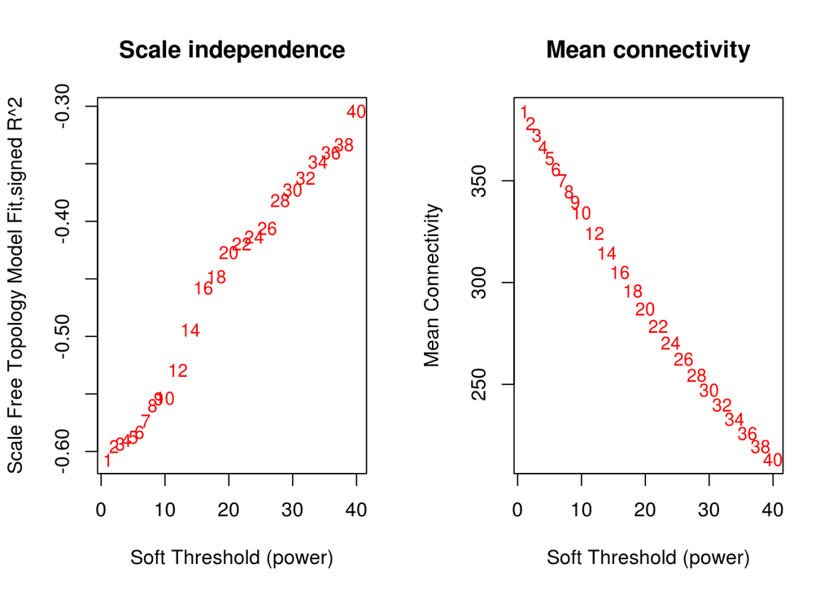

```r
par(mfrow = c(1,2));
cex1 = 0.9;
#scale-free topology fit index as function of soft-thresholding power
plot(sftA1$fitIndices[,1], -sign(sftA1$fitIndices[,3])*sftA1$fitIndices[,2],
xlab="Soft Threshold (power)",ylab="Scale Free Topology Model Fit,signed R^2",type="n",
main = paste("Scale independence"));
text(sftA1$fitIndices[,1], -sign(sftA1$fitIndices[,3])*sftA1$fitIndices[,2],
labels=powers,cex=cex1,col="red");
#this line corresponds to using R^2 cut-off of h
abline(h=0.90,col="red")
# Mean connectivity as a function of the soft-thresholding power
plot(sftA1$fitIndices[,1], sftA1$fitIndices[,5],
xlab="Soft Threshold (power)",ylab="Mean Connectivity", type="n",
main = paste("Mean connectivity"))
text(sftA1$fitIndices[,1], sftA1$fitIndices[,5], labels=powers, cex=cex1,col="red")
```

```r
dev.print(pdf, "Step16_plot_A1_auto-power_plot.pdf",height=10,width=18)
```

```r
#sftA1$powerEstimate is systems best guess
softPowerA1=sftA1$powerEstimate
softPowerA1
```

```
## [1] NA
```

```r
#set soft power to value 12 for signed networks if above automatic detection detects low power.
softPowerA1=12
```

```r
#Calculate weighted adjacency by uncommenting line below
adjacencyA1 = adjacency(t(datExprA1g2),power=softPowerA1,type="signed");
#here loading previously prepared adjacencyA1 by uncommenting line below
#load(file="adjacencyA1.RData")

diag(adjacencyA1)=0
#Turn adjacency into topology overlap matrix by uncommenting line below
TOM=TOMsimilarity(adjacencyA1, TOMType="signed")
```

```
## ..connectivity..
## ..matrix multiplication (system BLAS)..
## ..normalization..
## ..done.
```

```r
#here loading previously prepared TOM by uncommenting line below
#load(file="TOM.RData")

#Calculate dissTOMA1 by uncommenting line below
dissTOMA1 = 1-TOM
#here loading previously prepared dissTOMA1 by uncommenting line below
#load(file="dissTOMA1.RData")

#Hierarchial clustering based on TOM
geneTreeA1 = flashClust(as.dist(dissTOMA1), method="average")
```

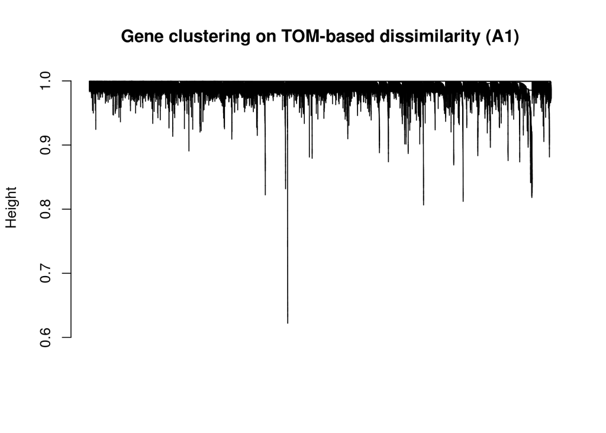

```r
#Display the networks visually:
#pdf("dendrogram.pdf",height=6,width=16)
#par(mar=c(1,1,1,1))
#par(mfrow=c(1,2))
plot(geneTreeA1,xlab="",sub="",main="Gene clustering on TOM-based dissimilarity (A1)",
labels=FALSE,hang=0.04);
```

```r
#dev.off()
dev.print(pdf,file="Step16_plot_dendrogram.pdf",height=5,width=10)
```

```r
#Modules for dataset A1 or modulesA1, cutHeight can be changed to adjust module size and reduce grey or unasigned module size based on cluster dendrogram plot height
mColorh=NULL
mColorhL=NULL
for (ds in 0:3){
tree = cutreeHybrid(dendro = geneTreeA1, pamStage=TRUE,
minClusterSize = (30-3*ds), cutHeight = 1.00,
deepSplit = ds, distM = dissTOMA1)
mColorh=cbind(mColorh,labels2colors(tree$labels));
mColorhL=cbind(mColorhL, paste("HuAgeGBsplit_", str_pad(tree$labels, 2, pad="0"), sep="" ))
}
```

```
##  ..done.
##  ..done.
##  ..done.
##  ..done.
```

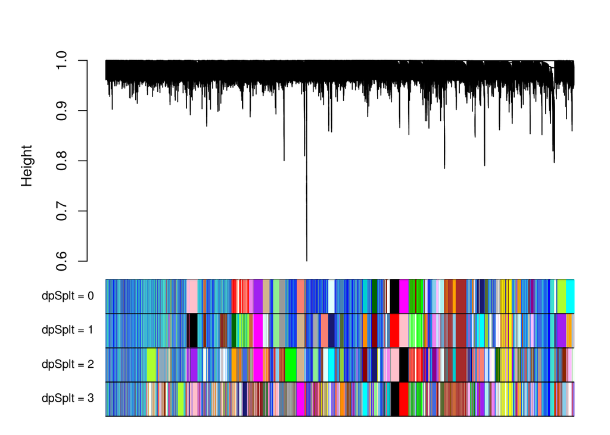

```r
#pdf("Module_choices.pdf", height=10,width=25);
plotDendroAndColors(geneTreeA1, mColorh, paste("dpSplt =",0:3), main = "",dendroLabels=FALSE);
```

```r
#dev.off()
dev.print(pdf,file="Step16_plot_Module_choices.pdf", height=5,width=10)
```

```r
#Picked deepSplit or dpSplit 2 which gives small number of large modules
modulesA1 = mColorh[,3] #color labels of modules
modulesA1L= mColorhL[,3] #numeric label of modules
#number of genes per module
```

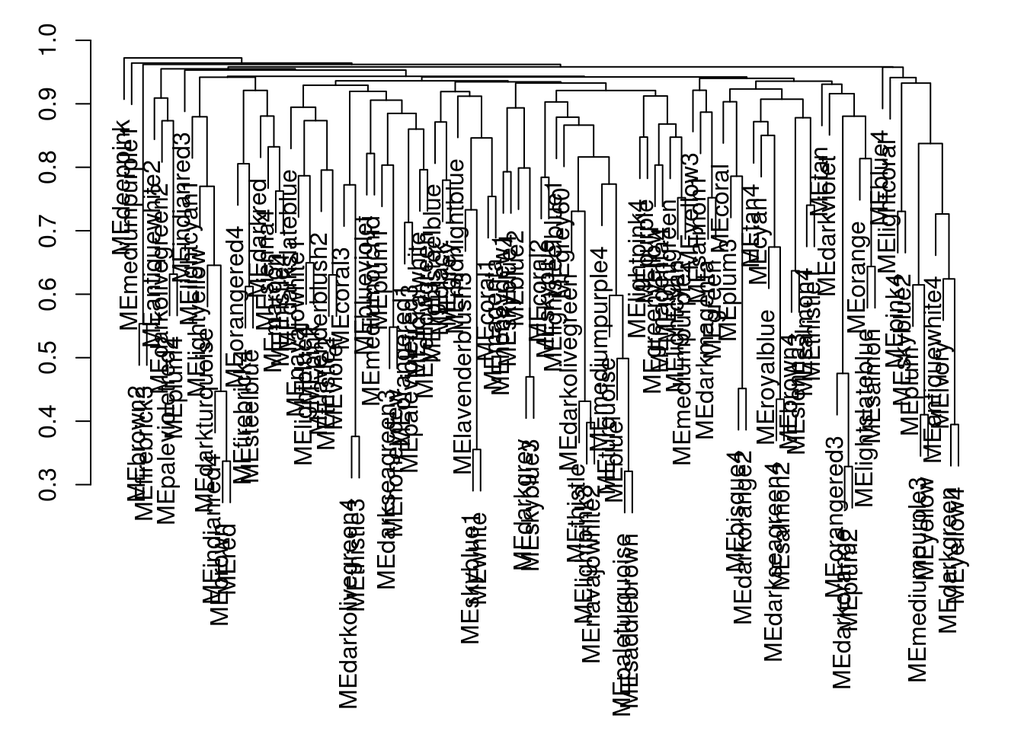

```r
#Principal component for visualization
PCs1A = moduleEigengenes(t(datExprA1g2), colors=modulesA1)
ME_1A = PCs1A$eigengenes
distPC1A = 1-abs(cor(ME_1A,use="p"))
distPC1A = ifelse(is.na(distPC1A), 0, distPC1A)
pcTree1A = hclust(as.dist(distPC1A),method="a")
MDS_1A = cmdscale(as.dist(distPC1A),2)
colorsA1 = names(table(modulesA1))

par(mfrow=c(1,1), mar=c(0, 3, 1, 1) + 0.1, cex=1)
plot(pcTree1A, xlab="",ylab="",main="",sub="")
```

```r
dev.print(pdf,file="Step16_plot_ModuleEigengeneVisualizationsTree.pdf",height=5,width=10)
```

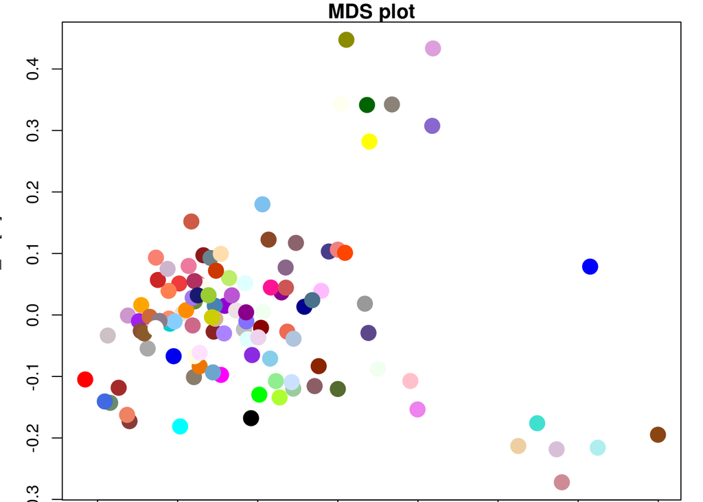

```r
par(mfrow=c(1,1), mar=c(0, 3, 1, 1) + 0.1, cex=1)
plot(MDS_1A, col= colorsA1, main="MDS plot", cex=2, pch=19)
```

```r
dev.print(pdf,file="Step16_plot_ModuleEigengeneVisualizationsMDS.pdf",height=5,width=5)
```

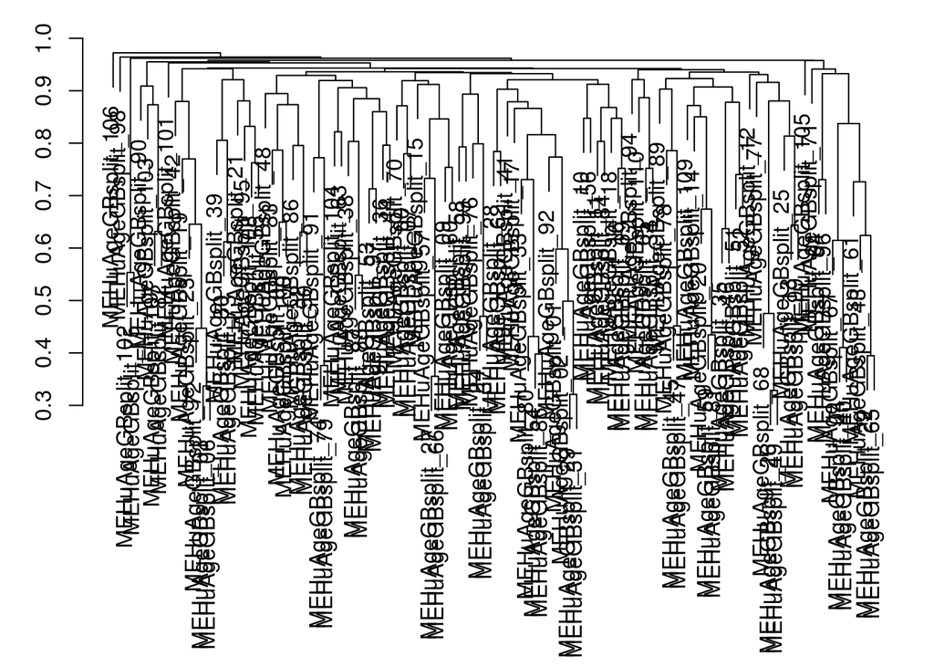

```r
PCs1AL = moduleEigengenes(t(datExprA1g2), colors=modulesA1L)
ME_1AL = PCs1AL$eigengenes
distPC1AL = 1-abs(cor(ME_1AL,use="p"))
distPC1AL = ifelse(is.na(distPC1AL), 0, distPC1AL)
pcTree1AL = hclust(as.dist(distPC1AL),method="a")
MDS_1AL = cmdscale(as.dist(distPC1AL),2)
colorsA1L = names(table(modulesA1L))

par(mfrow=c(1,1), mar=c(0, 3, 1, 1) + 0.1, cex=1)
plot(pcTree1AL, xlab="",ylab="",main="",sub="")
```

```r
dev.print(pdf,file="Step16_plot_ModuleEigengeneVisualizationsTreelabels.pdf",height=5,width=10)
```

```r
par(mfrow=c(1,1), mar=c(0, 3, 1, 1) + 0.1, cex=1)
#plot(MDS_1AL, col= colorsA1L, main="MDS plot", cex=2, pch=19)
#dev.print(pdf,file="Step16_plot_ModuleEigengeneVisualizationsMDSlabels.pdf",height=5,width=5)
```

### Step17A: Module membership (kME) for network comparison and identification of hub genes

```r
#kME to measure of correlations between each gene and each ME
#for data A1
geneModuleMembership1 = signedKME(t(datExprA1g2), ME_1A)
colnames(geneModuleMembership1)=paste("PC",colorsA1,".cor",sep="");
MMPvalue1=corPvalueStudent(as.matrix(geneModuleMembership1),dim(datExprA1g2)[[2]]);
colnames(MMPvalue1)=paste("PC",colorsA1,".pval",sep="");
Gene = rownames(datExprA1g2)
kMEtable1 = cbind(Gene,Gene,modulesA1)
for (i in 1:length(colorsA1))
kMEtable1 = cbind(kMEtable1, geneModuleMembership1[,i], MMPvalue1[,i])
colnames(kMEtable1)=c("PSID","Gene","Module",sort(c(colnames(geneModuleMembership1),
colnames(MMPvalue1))))
write.csv(kMEtable1,"Step17A_result_kMEtable1colors.csv")
```

```r
#Hub genes are genes that show significant correlation with MEs and high within-module connectivity
#kME values are used to compare data A1 to determine which genes have extremely high kME values in networks
#and are thus genes are hubs in both networks
#ref: modified from https://support.bioconductor.org/p/94701/
topGenesKME = NULL
for (c in 1:length(colorsA1)){
kMErank1 = rank(-geneModuleMembership1[,c])
#maxKMErank = rank(apply(cbind(kMErank1,kMErank2+.00001),1,max))
#topGenesKME = cbind(topGenesKME,Gene[maxKMErank<=10])
topGenesKME = cbind(topGenesKME,Gene[order(kMErank1, decreasing=FALSE)][1:10])
}
colnames(topGenesKME) = colorsA1
topGenesKME
```

```
##       antiquewhite2 antiquewhite4 bisque4   black        blue
##  [1,] "REN"         "C5orf17"     "PPIL2"   "AC084048.1" "LINC01643"
##  [2,] "LINC00303"   "MTCO2P23"    "UBE2L3"  "AC005772.1" "LINC01307"
##  [3,] "RBBP5"       "AP006295.1"  "HPS4"    "HNRNPCL1"   "AC092650.1"
##  [4,] "AL512306.3"  "AC004160.1"  "RANBP1"  "AL139390.1" "AC005580.1"
##  [5,] "AL606489.1"  "AC113347.4"  "SMARCB1" "HSPA8P13"   "AC023669.2"
##  [6,] "SNRPE"       "RNU6-284P"   "ESS2"    "CLNK"       "LINC01350"
##  [7,] "IL17REL"     "LINC01685"   "THAP7"   "ZSWIM2"     "AC091114.1"
##  [8,] "DSTYK"       "AC063952.1"  "TFIP11"  "AC092098.1" "AL157714.2"
##  [9,] "MDM4"        "MTND1P20"    "PEX26"   "PRSS38"     "AC091939.1"
## [10,] "PLEKHA6"     "AP002759.1"  "MED15"   "LGALS9C"    "LINC01681"
##       blue2        blue4        blueviolet   brown       brown2
##  [1,] "FOXR1"      "LYZL2"      "AC020551.1" "OR5AN1"    "C12orf77"
##  [2,] "RPL5P35"    "SVILP1"     "AC099786.1" "TDRD15"    "AL138889.1"
##  [3,] "AC090095.1" "RNU6-557P"  "AC087399.1" "CRISP2"    "EIF2S3B"
```

[output cut: 238 more lines]

```r
write.csv(topGenesKME,"Step17A_result_A1_HubGenestopGenesKMEcolorsRankSorted.csv")
#These genes or probes represent the top 10 hub genes for modules in data A1 networks.
```

```r
#Hub genes are genes that show significant correlation with MEs and high within-module connectivity
#kME values are used to compare data A1 to determine which genes have extremely high kME values in networks
#and are thus genes are hubs in both networks
topGenesKME = NULL
for (c in 1:length(colorsA1)){
kMErank1 = rank(-geneModuleMembership1[,c])
maxKMErank = rank(apply(cbind(kMErank1),1,max))
#maxKMErank = rank(apply(cbind(kMErank1,kMErank2+.00001),1,max))
topGenesKME = cbind(topGenesKME,Gene[maxKMErank<=10])
}
colnames(topGenesKME) = colorsA1
topGenesKME
```

```
##       antiquewhite2 antiquewhite4 bisque4   black        blue
##  [1,] "MDM4"        "RNU6-284P"   "THAP7"   "AC092098.1" "LINC01350"
##  [2,] "SNRPE"       "MTCO2P23"    "RANBP1"  "HNRNPCL1"   "LINC01307"
##  [3,] "PLEKHA6"     "MTND1P20"    "HPS4"    "ZSWIM2"     "AC005580.1"
##  [4,] "AL512306.3"  "AC063952.1"  "PEX26"   "HSPA8P13"   "AL157714.2"
##  [5,] "REN"         "C5orf17"     "ESS2"    "AL139390.1" "LINC01681"
##  [6,] "RBBP5"       "AP006295.1"  "SMARCB1" "LGALS9C"    "AC091114.1"
##  [7,] "AL606489.1"  "AP002759.1"  "MED15"   "AC084048.1" "AC023669.2"
##  [8,] "DSTYK"       "AC004160.1"  "PPIL2"   "PRSS38"     "LINC01643"
##  [9,] "LINC00303"   "LINC01685"   "UBE2L3"  "AC005772.1" "AC092650.1"
## [10,] "IL17REL"     "AC113347.4"  "TFIP11"  "CLNK"       "AC091939.1"
##       blue2        blue4        blueviolet   brown       brown2
##  [1,] "AC020914.2" "LYZL2"      "KERA"       "OR6C6"     "AC135584.1"
##  [2,] "FOXR1"      "RNU5F-6P"   "AL157937.1" "OR5T2"     "OR4A16"
##  [3,] "KRTAP9-1"   "RNA5SP62"   "AC099786.3" "TDRD15"    "MYO1A"
```

[output cut: 238 more lines]

```r
write.csv(topGenesKME,"Step17A_result_A1_HubGenestopGenesKMEcolorsRankUnsorted.csv")
#These genes or probes represent the top 10 hub genes for modules in data A1 networks.
```

# Same as above for labeled modules

```r
#kME to measure of correlations between each gene and each ME
#for data A1
geneModuleMembership1L = signedKME(t(datExprA1g2), ME_1AL)
colnames(geneModuleMembership1L)=paste("PC",colorsA1L,".cor",sep="");
MMPvalue1L=corPvalueStudent(as.matrix(geneModuleMembership1L),dim(datExprA1g2)[[2]]);
colnames(MMPvalue1L)=paste("PC",colorsA1L,".pval",sep="");
GeneL = rownames(datExprA1g2)
kMEtable1L = cbind(GeneL,GeneL,modulesA1L)
for (i in 1:length(colorsA1L))
kMEtable1L = cbind(kMEtable1L, geneModuleMembership1L[,i], MMPvalue1L[,i])
colnames(kMEtable1L)=c("PSID","Gene","Module",sort(c(colnames(geneModuleMembership1L),
colnames(MMPvalue1L))))
write.csv(kMEtable1L,"Step17A_result_kMEtable1labels.csv")
```

```r
#Hub genes are genes that show significant correlation with MEs and high within-module connectivity
#kME values are used to compare data A1 to determine which genes have extremely high kME values in networks
#and are thus genes are hubs in both networks
#ref: modified from https://support.bioconductor.org/p/94701/
topGenesKMEL = NULL
for (c in 1:length(colorsA1L)){
kMErank1L = rank(-geneModuleMembership1L[,c])
#maxKMErank = rank(apply(cbind(kMErank1,kMErank2+.00001),1,max))
#topGenesKMEL = cbind(topGenesKMEL,GeneL[maxKMErankL<=10])
topGenesKMEL = cbind(topGenesKMEL,GeneL[order(kMErank1L, decreasing=FALSE)][1:10])
}
colnames(topGenesKMEL) = colorsA1L
topGenesKMEL
```

```
##       HuAgeGBsplit_00 HuAgeGBsplit_01 HuAgeGBsplit_02 HuAgeGBsplit_03
##  [1,] "DLG1"          "LINC00351"     "LINC01643"     "OR5AN1"
##  [2,] "PIGZ"          "LINC00393"     "LINC01307"     "TDRD15"
##  [3,] "ATP13A3"       "LINC00301"     "AC092650.1"    "CRISP2"
##  [4,] "OPA1"          "NALCN-AS1"     "AC005580.1"    "OR6C6"
##  [5,] "PAK2"          "AC096577.1"    "AC023669.2"    "TMPRSS11B"
##  [6,] "PPP1R2"        "LINC02267"     "LINC01350"     "CSN3"
##  [7,] "ACAP2"         "LINC02532"     "AC091114.1"    "OR6C1"
##  [8,] "PIGX"          "AL591518.1"    "AL157714.2"    "OR4F13P"
##  [9,] "UBXN7"         "AC004704.1"    "AC091939.1"    "OR5T2"
## [10,] "ULK2"          "AC027613.1"    "LINC01681"     "AMTN"
##       HuAgeGBsplit_04 HuAgeGBsplit_05 HuAgeGBsplit_06 HuAgeGBsplit_07
##  [1,] "AC019211.1"    "CTDSPL2"       "WFDC5"         "AC084048.1"
##  [2,] "AC067956.1"    "ARIH1"         "BPIFA1"        "AC005772.1"
##  [3,] "LINGO2"        "TRPM7"         "C20orf173"     "HNRNPCL1"
```

[output cut: 293 more lines]

```r
write.csv(topGenesKMEL,"Step17A_result_A1_HubGenestopGenesKMElabelsRankSorted.csv")
#These genes or probes represent the top 10 hub genes for modules in data A1 networks.
```

```r
#Hub genes are genes that show significant correlation with MEs and high within-module connectivity
#kME values are used to compare data A1 to determine which genes have extremely high kME values in networks
#and are thus genes are hubs in both networks
topGenesKMEL = NULL
for (c in 1:length(colorsA1L)){
kMErank1L = rank(-geneModuleMembership1L[,c])
maxKMErankL = rank(apply(cbind(kMErank1L),1,max))
#maxKMErank = rank(apply(cbind(kMErank1,kMErank2+.00001),1,max))
topGenesKMEL = cbind(topGenesKMEL,GeneL[maxKMErankL<=10])
}
colnames(topGenesKMEL) = colorsA1L
topGenesKMEL
```

```
##       HuAgeGBsplit_00 HuAgeGBsplit_01 HuAgeGBsplit_02 HuAgeGBsplit_03
##  [1,] "PIGZ"          "LINC02532"     "LINC01350"     "OR6C6"
##  [2,] "ULK2"          "AL591518.1"    "LINC01307"     "OR5T2"
##  [3,] "ATP13A3"       "NALCN-AS1"     "AC005580.1"    "TDRD15"
##  [4,] "PPP1R2"        "LINC00351"     "AL157714.2"    "OR4F13P"
##  [5,] "UBXN7"         "LINC00301"     "LINC01681"     "CSN3"
##  [6,] "PIGX"          "LINC00393"     "AC091114.1"    "OR5AN1"
##  [7,] "ACAP2"         "AC096577.1"    "AC023669.2"    "OR6C1"
##  [8,] "PAK2"          "AC004704.1"    "LINC01643"     "TMPRSS11B"
##  [9,] "OPA1"          "LINC02267"     "AC092650.1"    "CRISP2"
## [10,] "DLG1"          "AC027613.1"    "AC091939.1"    "AMTN"
##       HuAgeGBsplit_04 HuAgeGBsplit_05 HuAgeGBsplit_06 HuAgeGBsplit_07
##  [1,] "NEGR1"         "ZSCAN29"       "NEU2"          "AC092098.1"
##  [2,] "KHDRBS2"       "RTF1"          "LGALS16"       "HNRNPCL1"
##  [3,] "LINGO2"        "EIF2AK4"       "WFDC5"         "ZSWIM2"
```

[output cut: 293 more lines]

```r
write.csv(topGenesKMEL,"Step17A_result_A1_HubGenestopGenesKMElabelsRankUnsorted.csv")
#These genes or probes represent the top 10 hub genes for modules in data A1 networks.
```

### Step17B: Intramodular connectivity (kIM or kWithin) and whole network connectivity (kTotal) for network comparison

```r
#Ref: WGCNA tutorial Steve Horvath Peter Langfelder 2011
#intramodular connectivity is mathematically the sum of module edge weights or "degree" of connectivity between a given node or gene and other genes or nodes within the module.
#For colors
IntraModularConnectivity1=intramodularConnectivity(adjacencyA1,modulesA1)
```

```r
#We get the color labels for the genes
GeneModule1=kMEtable1[,c("PSID","Gene","Module")]
rownames(GeneModule1)=rownames(kMEtable1)
```

```r
#merge the intramodular connectivity dataframe with module names by rownames that are gene symbols
IntraModularConnectivity2=merge(GeneModule1,IntraModularConnectivity1, by="row.names")
#drop the extra row.name column
IntraModularConnectivity3=IntraModularConnectivity2[,-c(1)]
DT::datatable(head(IntraModularConnectivity3))
```

|  | PSID | Gene | Module | kTotal | kWithin | kOut | kDiff |
| --- | --- | --- | --- | --- | --- | --- | --- |
| 1 | A1BG | A1BG | skyblue | 10.3539020250183 | 0.229397626806555 | 10.1245043982118 | -9.89510677140522 |
| 2 | A2M | A2M | yellow | 9.81914248054878 | 0.43486148436481 | 9.38428099618396 | -8.94941951181915 |
| 3 | A2M-AS1 | A2M-AS1 | blue | 9.68029280573507 | 1.32953960823902 | 8.35075319749605 | -7.02121358925703 |
| 4 | A2ML1 | A2ML1 | turquoise | 10.244218209544 | 1.76034210538143 | 8.48387610416255 | -6.72353399878112 |
| 5 | A2ML1-AS1 | A2ML1-AS1 | turquoise | 10.8893823377929 | 2.3334768064046 | 8.55590553138831 | -6.22242872498371 |
| 6 | A2MP1 | A2MP1 | tan | 16.1444562753139 | 6.92972309520789 | 9.21473318010599 | -2.2850100848981 |

```r
#export kWithin and kTotal for all genes
write.csv(IntraModularConnectivity3,"Step17B_result_kWithintable1colors.csv")
```

```r
#Abbreviation IntraModularConnectivity3=IMC3
IMC3=IntraModularConnectivity3

#Export genes ranked by Intramodular connectivity for each module
for (i in unique(IMC3$Module)){

  #Select modules
  modules= i
  modules

  #net gene Connectivity or weights is a.k.a. kIM or IM or kWithin
  IMC3_sel=IMC3[which(IMC3$Module==modules),] #select those rows which match module name
  IMC3_sort=IMC3_sel[order(-IMC3_sel$kWithin),] #order by stronger to weaker connectivity

  #net gene Connectivity ranks
  IMC3_sort$rank<- rank(-(IMC3_sort$kWithin)) #This gives the highest kWithin the highest rank
  #export output
  write.table(IMC3_sort, paste0("ForGenesInModule-", modules, "-RankedByIntraModularConnectivity3.txt", sep=""),row.names=F, quote=F)
}
```

# Same as above for labeled modules

```r
#Ref: WGCNA tutorial Steve Horvath Peter Langfelder 2011
#intramodular connectivity is mathematically the sum of module edge weights or "degree" of connectivity between a given node or gene and other genes or nodes within the module.
#For colors
IntraModularConnectivity1L=intramodularConnectivity(adjacencyA1,modulesA1L)
```

```r
#We get the number labels for the genes
GeneModule1L=kMEtable1L[,c("PSID","Gene","Module")]
rownames(GeneModule1L)=rownames(kMEtable1L)
```

```r
#merge the intramodular connectivity dataframe with module names by rownames that are gene symbols
IntraModularConnectivity2L=merge(GeneModule1L,IntraModularConnectivity1L, by="row.names")
#drop the extra row.name column
IntraModularConnectivity3L=IntraModularConnectivity2L[,-c(1)]
DT::datatable(head(IntraModularConnectivity3L))
```

|  | PSID | Gene | Module | kTotal | kWithin | kOut | kDiff |
| --- | --- | --- | --- | --- | --- | --- | --- |
| 1 | A1BG | A1BG | HuAgeGBsplit_28 | 10.3539020250183 | 0.229397626806555 | 10.1245043982118 | -9.89510677140522 |
| 2 | A2M | A2M | HuAgeGBsplit_04 | 9.81914248054878 | 0.43486148436481 | 9.38428099618396 | -8.94941951181915 |
| 3 | A2M-AS1 | A2M-AS1 | HuAgeGBsplit_02 | 9.68029280573507 | 1.32953960823902 | 8.35075319749605 | -7.02121358925703 |
| 4 | A2ML1 | A2ML1 | HuAgeGBsplit_01 | 10.244218209544 | 1.76034210538143 | 8.48387610416255 | -6.72353399878112 |
| 5 | A2ML1-AS1 | A2ML1-AS1 | HuAgeGBsplit_01 | 10.8893823377929 | 2.3334768064046 | 8.55590553138831 | -6.22242872498371 |
| 6 | A2MP1 | A2MP1 | HuAgeGBsplit_12 | 16.1444562753139 | 6.92972309520789 | 9.21473318010599 | -2.2850100848981 |

```r
#export kWithin and kTotal for all genes
write.csv(IntraModularConnectivity3L,"Step17B_result_kWithintable1labels.csv")
```

```r
#Abbreviation IntraModularConnectivity3L=IMC3L
IMC3L=IntraModularConnectivity3L

#Export genes ranked by Intramodular connectivity for each module
for (i in unique(IMC3L$Module)){

  #Select modules
  modules= i
  modules

  #net gene Connectivity or weights is a.k.a. kIM or IM or kWithin
  IMC3L_sel=IMC3L[which(IMC3L$Module==modules),] #select those rows which match module name
  IMC3L_sort=IMC3L_sel[order(-IMC3L_sel$kWithin),] #order by stronger to weaker connectivity

  #net gene Connectivity ranks
  IMC3L_sort$rank<- rank(-(IMC3L_sort$kWithin)) #This gives the highest kWithin the highest rank
  #export output
  write.table(IMC3L_sort, paste0("ForGenesInModule-", modules, "-RankedByIntraModularConnectivity3L.txt", sep=""),row.names=F, quote=F)
}
```

### Step18: Generating individual txt files containing genes in a given module

```r
#Make a folder first called 'Module_GeneskMEHubs' change full path below as per your system
dir.create("./Module_GeneskMEHubs")
folder = "Module_GeneskMEHubs/"
for (c in colorsA1){
fn = paste(folder, c, ".txt",sep="");
write.geneList(Gene[modulesA1==c], fn)
};
write(Gene,paste(folder,"all.txt",sep=""))
#The folder should now have files titled "<color>.txt" that contain the gene names of every gene in that module,as well as a file titled "all.txt" that has every gene in your data set.
```

```r
#make a summary file of all the genes in modules, similar to kME files but with only genes and module names as above
geneListsModuleSummary=cbind(Gene,modulesA1)
write.csv(geneListsModuleSummary,"Step18_result_geneListsModuleSummarycolors.csv")
```

# Same as above for labeled modules

```r
#Make a folder first called 'Module_GeneskMEHubs' change full path below as per your system
folder = "Module_GeneskMEHubs/"
for (c in colorsA1L){
fn = paste(folder, c, ".txt",sep="");
write.geneList(GeneL[modulesA1L==c], fn)
};
write(GeneL,paste(folder,"allL.txt",sep=""))
#The folder should now have files titled "<color>.txt" that contain the gene names of every gene in that module,as well as a file titled "all.txt" that has every gene in your data set.
```

```r
#make a summary file of all the genes in modules, similar to kME files but with only genes and module names as above
geneListsModuleSummaryL=cbind(GeneL,modulesA1L)
write.csv(geneListsModuleSummaryL,"Step18_result_geneListsModuleSummarylabels.csv")
```

### Step19: Visualization of trait module relatonships for data A1

# In this step we use the coded metadata files

# Relating modules to physiological traits for A1

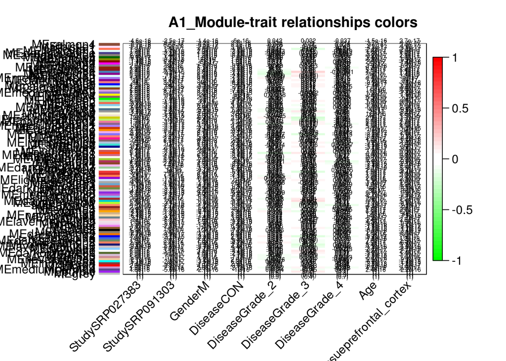

```r
# For data A1
# Define numbers of genes and samples
nGenesA1 = nrow(datExprA1g2)
nSamplesA1 = ncol(datExprA1g2)
# Recalculate MEs with color labels
MEs0A1= moduleEigengenes(t(datExprA1g2),modulesA1)$eigengenes
MEsA1= orderMEs(MEs0A1)
modTraitCorA1 = cor(MEsA1, metadataA1g_coded, use = "p")
#modTraitCorA1 = cor(MEsA1, metadataA1g_coded, use="complete.obs", method = c("pearson", "kendall", "spearman"))
modTraitPA1 = corPvalueStudent(modTraitCorA1, nSamplesA1)
textMatrixA1 = paste(signif(modTraitCorA1, 2), "\n(",
signif(modTraitPA1, 1), ")", sep = "")
dim(textMatrixA1) = dim(modTraitCorA1)
par(mar = c(6, 8.5, 3, 3))
# Display the correlation values within a heatmap plot
labeledHeatmap(Matrix = modTraitCorA1, xLabels = names(metadataA1g_coded),
yLabels = names(MEsA1), ySymbols = names(MEsA1),
colorLabels =FALSE,colors=greenWhiteRed(50),textMatrix=textMatrixA1,
setStdMargins = FALSE, cex.text = 0.5, zlim = c(-1,1),
main = paste("A1_Module-trait relationships colors"))
```

```r
dev.print(pdf,"Step19_plot_A1_relating modules to trait colors.pdf", width=5, height=5)
```

```r
#This is for color module trait table
colnames(modTraitPA1) = paste("p.value.", colnames(modTraitCorA1), sep="");
out3<-cbind(Module=rownames(modTraitCorA1), modTraitCorA1, modTraitPA1)
dim(out3)
```

```
## [1] 111  19
```

```r
write.table(out3, "Step19_result_A1_relating modules to trait colors.csv", sep=",",row.names=F)
```

# Same as above for labeled modules

# Relating modules to physiological traits for A1

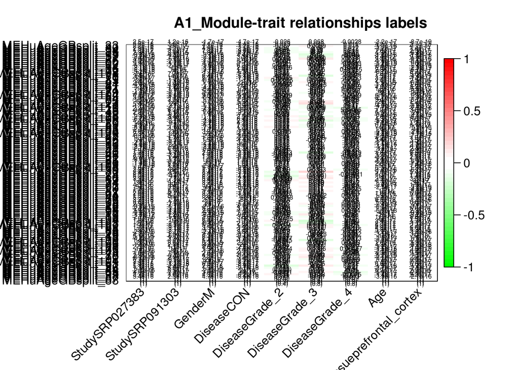

```r
# For data A1
# Define numbers of genes and samples
nGenesA1L = nrow(datExprA1g2)
nSamplesA1L = ncol(datExprA1g2)
# Recalculate MEs with color labels
MEs0A1L= moduleEigengenes(t(datExprA1g2),modulesA1L)$eigengenes
MEsA1L= orderMEs(MEs0A1L)
modTraitCorA1L = cor(MEsA1L, metadataA1g_coded, use = "p")
#modTraitCorA1L = cor(MEsA1L, metadataA1g_coded, use="complete.obs", method = c("pearson", "kendall", "spearman"))
modTraitPA1L = corPvalueStudent(modTraitCorA1L, nSamplesA1L)
textMatrixA1L = paste(signif(modTraitCorA1L, 2), "\n(",
signif(modTraitPA1L, 1), ")", sep = "")
dim(textMatrixA1L) = dim(modTraitCorA1L)
par(mar = c(6, 8.5, 3, 3))
# Display the correlation values within a heatmap plot
labeledHeatmap(Matrix = modTraitCorA1L, xLabels = names(metadataA1g_coded),
yLabels = names(MEsA1L), ySymbols = names(MEsA1L),
colorLabels =FALSE,colors=greenWhiteRed(50),textMatrix=textMatrixA1L,
setStdMargins = FALSE, cex.text = 0.5, zlim = c(-1,1),
main = paste("A1_Module-trait relationships labels"))
```

```r
dev.print(pdf,"Step19_plot_A1_relating modules to trait labels.pdf", width=5, height=5)
```

```r
#This is for label module trait table
colnames(modTraitPA1L) = paste("p.value.", colnames(modTraitCorA1L), sep="");
out3L<-cbind(Module=rownames(modTraitCorA1L), modTraitCorA1L, modTraitPA1L)
dim(out3L)
```

```
## [1] 111  19
```

```r
write.table(out3L, "Step19_result_A1_relating modules to trait labels.csv", sep=",",row.names=F)
```

```r
#Gene trait significance and correlation for entire gene set i.e. all genes from all modules
geneTraitCorA1 = cor(t(datExprA1g2), metadataA1g_coded, use = "p")
geneTraitPA1 = corPvalueStudent(geneTraitCorA1, nSamplesA1)
#This is for color gene trait table
colnames(geneTraitPA1) = paste("p.value.", colnames(geneTraitCorA1), sep="");
out3gene<-cbind(GeneName=rownames(geneTraitCorA1), geneTraitCorA1, geneTraitPA1)
dim(out3gene)
```

```
## [1] 30964    19
```

```r
write.table(out3gene, "Step19_result_A1_relating all genes to traits.csv", sep=",",row.names=F)
```

```r
#save.image(file="temp.RData")
#rm(list=ls())
#gc()
#To reload uncomment code below
#load(file="temp.RData")
```

### Step20: Cross-pipeline preservation and hypergeometric test: Qualitatively and quantitatively measure cross-species, cross-pipeline and/or any cross-dataset network preservation at the module level

# Will export the files for preservation analysis and hypergeometric test

```r
#Export expression file
write.csv(datExprA1g2,"Step20_result_ForPres&Hyper_HuAgeGBsplit_datExprA1g2.csv")
#Export the module and gene names for use Preservation and hypergeometric test
write.csv(kMEtable1[,c("PSID","Gene","Module")],"Step20_result_ForPres&Hyper_HuAgeGBsplit_GeneModule.csv")
write.csv(kMEtable1L[,c("PSID","Gene","Module")],"Step20_result_ForPres&Hyper_HuAgeGBsplit_GeneModuleL.csv")
```

### Step21: Enrichment of cell types in modules

```r
celltype=read.csv("./InputMetadata&Lists/CellType_ImmuneCells_StemCells_Full_Hu.csv",sep=',')
cellTypeGeneCount=as.data.frame(table(celltype$Category))
cellTypeGeneCount
```

```
##                                 Var1 Freq
## 1                      aNP_BY_qRP_up   68
## 2                      aRG_BY_qRG_up  113
## 3                        astroBYoFC5 1078
## 4     AstroByothersCuffdiff2FCover20  455
## 5                         endoBYoFC5  368
## 6   EndotheByothersCuffdiff2FCover20  603
## 7                  GSCbyNSC_BFover5_ 1414
## 8      MacroByMicroCuffdiff2FCover20  219
## 9                  macrophagesBYoFC5  394
## 10     MicroByMacroCuffdiff2FCover20  460
## 11      MicroByMonoCuffdiff2FCover20  457
## 12                   microgliaBYoFC5  274
## 13 MicrogliByothersCuffdiff2FCover20 1162
## 14      MonoByMicroCuffdiff2FCover20  809
## 15                   monocytesBYoFC5  373
## 16                    myeoligoBYoFC5   85
## 17 MyeOligoByothersCuffdiff2FCover20  263
## 18                      neuronBYoFC5  653
## 19   NeuronByothersCuffdiff2FCover20  704
## 20                    newoligoBYoFC5  110
## 21 NewOligoByothersCuffdiff2FCover20   82
## 22                     npcBYnsc_FC5_ 1090
## 23                     nscBYnpc_FC5_  824
## 24                    preoligoBYoFC5   25
## 25 PreOligoByothersCuffdiff2FCover20  116
## 26                     qnpBYtap_FC5_ 1644
## 27                     qRG_BY_aRG_up   91
## 28                     qRP_BY_aNP_up  262
## 29                     tapBYqnp_FC5_  868
```

```r
write.csv(cellTypeGeneCount,"CellTypeFullHuman_GSE68270_DEGup_FC5_Signature_Hu_GeneCount.csv")
```

```r
#This is the actual calulation of hypergeometric enrichment
enrichmentsCellTypeFullHuman = userListEnrichment(rownames(datExprA1g2), modulesA1,"./InputMetadata&Lists/CellType_ImmuneCells_StemCells_Full_Hu.csv", "", "enrichmentsCellTypeFullHuman_Sigificantcolors.csv")
```

```
## 3190 comparisons were successfully performed.
```

```r
#List of genes that overlap between modules and CellTypeFullHuman
enrichmentsCellTypeFullHuman_OvGenes=enrichmentsCellTypeFullHuman[[2]]
dir.create("./enrichmentsCellTypeFullHuman_OvGenes")
for (i in 1:length(enrichmentsCellTypeFullHuman_OvGenes)) {
  write.csv(enrichmentsCellTypeFullHuman_OvGenes[i], file=paste0("enrichmentsCellTypeFullHuman_OvGenes/", names(enrichmentsCellTypeFullHuman_OvGenes)[i], ".txt"))
}

#List of genes that overlap between modules and CellTypeFullHuman
enrichmentsCellTypeFullHuman_NumOvGenes_pvalue=enrichmentsCellTypeFullHuman[[1]]
write.csv(enrichmentsCellTypeFullHuman_NumOvGenes_pvalue,"enrichmentsCellTypeFullHuman_NumOvGenes_pvalue_colors.csv")
```

```r
geneListsModuleSummary=read.csv('Step18_result_geneListsModuleSummarycolors.csv', sep=',')
enrichmentsSummaryCellTypeFullHuman=read.csv('enrichmentsCellTypeFullHuman_NumOvGenes_pvalue_colors.csv', sep=',')
```

```r
geneListsModuleSummaryMod=table(geneListsModuleSummary$modulesA1)
geneListsModuleSummaryMod=as.data.frame(geneListsModuleSummaryMod)
write.csv(geneListsModuleSummaryMod, "geneListsModuleSummarycolors_GeneCount.csv")

colnames(geneListsModuleSummaryMod)=c("InputCategories", "Freq")
geneListsModuleSummaryMod
```

```
##     InputCategories Freq
## 1     antiquewhite2   60
## 2     antiquewhite4  117
## 3           bisque4  161
## 4             black  615
## 5              blue 4249
## 6             blue2   86
## 7             blue4   38
## 8        blueviolet   39
## 9             brown 1209
## 10           brown2   92
## 11           brown4  163
## 12            coral   61
## 13           coral1  120
## 14           coral2  114
```

[output cut: 97 more lines]

```r
enrichmentsSummaryCellTypeFullHumanmergeMod=merge(enrichmentsSummaryCellTypeFullHuman,geneListsModuleSummaryMod, by="InputCategories")
write.csv(enrichmentsSummaryCellTypeFullHumanmergeMod,"enrichmentsSummaryCellTypeFullHumanmergeMod_colors.csv")
```

# Same as above for labeled modules

```r
enrichmentsCellTypeFullHumanL = userListEnrichment(rownames(datExprA1g2), modulesA1L,"./InputMetadata&Lists/CellType_ImmuneCells_StemCells_Full_Hu.csv", "", "enrichmentsCellTypeFullHuman_Sigificantlabels.csv")
```

```
## 3219 comparisons were successfully performed.
```

```r
#List of genes that overlap between modules and CellTypeFullHuman
enrichmentsCellTypeFullHuman_OvGenesL=enrichmentsCellTypeFullHumanL[[2]]
for (i in 1:length(enrichmentsCellTypeFullHuman_OvGenesL)) {
  write.csv(enrichmentsCellTypeFullHuman_OvGenesL[i], file=paste0("enrichmentsCellTypeFullHuman_OvGenes/", names(enrichmentsCellTypeFullHuman_OvGenesL)[i], ".txt"))
}

#List of genes that overlap between modules and CellTypeFullHuman
enrichmentsCellTypeFullHuman_NumOvGenes_pvalueL=enrichmentsCellTypeFullHumanL[[1]]
write.csv(enrichmentsCellTypeFullHuman_NumOvGenes_pvalueL,"enrichmentsCellTypeFullHuman_NumOvGenes_pvalue_labels.csv")
```

```r
geneListsModuleSummaryL=read.csv('Step18_result_geneListsModuleSummarylabels.csv', sep=',')
enrichmentsSummaryCellTypeFullHumanL=read.csv('enrichmentsCellTypeFullHuman_NumOvGenes_pvalue_labels.csv', sep=',')
```

```r
geneListsModuleSummaryModL=table(geneListsModuleSummaryL$modulesA1L)
geneListsModuleSummaryModL=as.data.frame(geneListsModuleSummaryModL)
write.csv(geneListsModuleSummaryModL, "geneListsModuleSummarylabels_GeneCount.csv")

colnames(geneListsModuleSummaryModL)=c("InputCategories", "Freq")
enrichmentsSummaryCellTypeFullHumanmergeModL=merge(enrichmentsSummaryCellTypeFullHumanL,geneListsModuleSummaryModL, by="InputCategories")
write.csv(enrichmentsSummaryCellTypeFullHumanmergeModL,"enrichmentsSummaryCellTypeFullHumanmergeModL_labels.csv")
```

```r
toLatex(sessionInfo())
```

```
## \begin{itemize}\raggedright
##   \item R version 3.4.4 (2018-03-15), \verb|x86_64-pc-linux-gnu|
##   \item Locale: \verb|LC_CTYPE=en_US.UTF-8|, \verb|LC_NUMERIC=C|, \verb|LC_TIME=en_US.UTF-8|, \verb|LC_COLLATE=en_US.UTF-8|, \verb|LC_MONETARY=en_US.UTF-8|, \verb|LC_MESSAGES=en_US.UTF-8|, \verb|LC_PAPER=en_US.UTF-8|, \verb|LC_NAME=C|, \verb|LC_ADDRESS=C|, \verb|LC_TELEPHONE=C|, \verb|LC_MEASUREM…
##   \item Running under: \verb|Ubuntu 16.04.6 LTS|
##   \item Matrix products: default
##   \item BLAS: \verb|/usr/lib/libblas/libblas.so.3.6.0|
##   \item LAPACK: \verb|/usr/lib/lapack/liblapack.so.3.6.0|
##   \item Base packages: base, datasets, graphics, grDevices,
##     methods, stats, utils
##   \item Other packages: dynamicTreeCut~1.63-1, enrichR~1.0,
##     fastcluster~1.1.25, filesstrings~3.0.0, flashClust~1.01-2,
##     Formula~1.2-3, ggplot2~3.1.0, Hmisc~4.1-1, impute~1.52.0,
##     lattice~0.20-38, qvalue~2.10.0, stringi~1.2.4, stringr~1.3.1,
##     survival~2.43-3, WGCNA~1.66
##   \item Loaded via a namespace (and not attached): acepack~1.4.1,
##     AnnotationDbi~1.40.0, assertthat~0.2.0, backports~1.1.3,
##     base64enc~0.1-3, bindr~0.1.1, bindrcpp~0.2.2, Biobase~2.38.0,
##     BiocGenerics~0.24.0, bit~1.1-14, bit64~0.9-7, blob~1.1.1,
##     checkmate~1.8.5, cluster~2.0.7-1, codetools~0.2-16,
##     colorspace~1.3-2, compiler~3.4.4, crayon~1.3.4,
##     crosstalk~1.0.0, data.table~1.11.8, DBI~1.0.0, DEoptimR~1.0-8,
##     digest~0.6.18, doParallel~1.0.14, dplyr~0.7.8, DT~0.5,
##     evaluate~0.12, fit.models~0.5-14, foreach~1.4.4,
##     foreign~0.8-70, glue~1.3.0, GO.db~3.5.0, grid~3.4.4,
##     gridExtra~2.3, gtable~0.2.0, htmlTable~1.13, htmltools~0.3.6,
##     htmlwidgets~1.3, httpuv~1.4.5.1, httr~1.4.0, IRanges~2.12.0,
##     iterators~1.0.10, jsonlite~1.6, knitr~1.21, later~0.7.5,
##     latticeExtra~0.6-28, lazyeval~0.2.1, magrittr~1.5,
##     MASS~7.3-50, Matrix~1.2-14, matrixStats~0.54.0, memoise~1.1.0,
##     mime~0.6, munsell~0.5.0, mvtnorm~1.0-8, nnet~7.3-12,
##     parallel~3.4.4, pcaPP~1.9-73, pillar~1.3.1, pkgconfig~2.0.2,
##     plyr~1.8.4, preprocessCore~1.40.0, promises~1.0.1,
##     purrr~0.2.5, R6~2.3.0, RColorBrewer~1.1-2, Rcpp~1.0.0,
##     reshape2~1.4.3, rjson~0.2.20, rlang~0.3.0.1, rmarkdown~1.11,
##     robust~0.4-18, robustbase~0.93-3, rpart~4.1-13, rrcov~1.4-7,
##     RSQLite~2.1.1, rstudioapi~0.8, S4Vectors~0.16.0, scales~1.0.0,
##     shiny~1.2.0, splines~3.4.4, stats4~3.4.4, strex~0.1.3,
##     tibble~2.0.0, tidyselect~0.2.5, tools~3.4.4, withr~2.1.2,
##     xfun~0.4, xtable~1.8-3, yaml~2.2.0
## \end{itemize}
```

```r
#save image
save.image(file="WGCNA_temp.RData")
```

```r
#Organize of files
#library(filesstrings)

dir.create("Module_Trait_wgcnaRData")
file.move(list.files(pattern = 'A1_dat*'), "Module_Trait_wgcnaRData")
```

```
## 0 files moved. 0 failed.
```

```r
file.move(list.files(pattern = 'Step19_result_A1_relating*'), "Module_Trait_wgcnaRData")
```

```
## 3 files moved. 0 failed.
```

```r
file.move(list.files(pattern = 'Step19_plot_A1_relating*'), "Module_Trait_wgcnaRData")
```

```
## 2 files moved. 0 failed.
```

```r
file.move(list.files(pattern = 'SelectGeneListA1*'), "Module_Trait_wgcnaRData")
```

```
## 0 files moved. 0 failed.
```

```r
file.move(list.files(pattern = 'Step18_result_geneListsModuleSummary*'), "Module_Trait_wgcnaRData")
```

```
## 2 files moved. 0 failed.
```

```r
file.move(list.files(pattern = 'A1_datAge*'), "Module_Trait_wgcnaRData")
```

```
## 0 files moved. 0 failed.
```

```r
file.move(list.files(pattern = 'WGCNA_temp.RData'), "Module_Trait_wgcnaRData")
```

```
## 1 file moved. 0 failed.
```

```r
dir.create("Module_GenesRankskMEHubs")
file.move(list.files(pattern = "Step17A_result_A1_HubGenestop*"), "Module_GenesRankskMEHubs")
```

```
## 4 files moved. 0 failed.
```

```r
file.move(list.files(pattern = "Step20_result_ForPres&Hyper*"), "Module_GenesRankskMEHubs")
```

```
## 3 files moved. 0 failed.
```

```r
file.move(list.files(pattern = "Step17B_result_kWithin*"), "Module_GenesRankskMEHubs")
```

```
## 2 files moved. 0 failed.
```

```r
file.move(list.files(pattern = "Step17A_result_kMEtable1*"), "Module_GenesRankskMEHubs")
```

```
## 2 files moved. 0 failed.
```

```r
file.move(list.files(pattern = "kWithinConnectionskME*"), "Module_GenesRankskMEHubs")
```

```
## 0 files moved. 0 failed.
```

```r
file.move(list.files(pattern = "Step16_plot*"), "Module_GenesRankskMEHubs")
```

```
## 6 files moved. 0 failed.
```

```r
file.move(list.files(pattern = "*GeneCount.csv"), "Module_GenesRankskMEHubs")
```

```
## 3 files moved. 0 failed.
```

```r
dir.create("Module_GenesRankskwithin")
file.move(list.files(pattern = "ForGenesInModule*"), "Module_GenesRankskwithin")
```

```
## 222 files moved. 0 failed.
```

```r
file.move(list.files(pattern = 'enrichment_temp.RData'), "Module_Trait_wgcnaRData")
```

```
## 0 files moved. 0 failed.
```

```r
dir.create("enrichmentsCellTypeFullHuman_OvGenes")
file.move(list.files(pattern = "enrichmentsCellTypeFullHuman_Num*"), "enrichmentsCellTypeFullHuman_OvGenes")
```

```
## 2 files moved. 0 failed.
```

```r
file.move(list.files(pattern = "enrichmentsCellTypeFullHuman_Sig*"), "enrichmentsCellTypeFullHuman_OvGenes")
```

```
## 2 files moved. 0 failed.
```

```r
file.move(list.files(pattern = "enrichmentsSummaryCellTypeFullHuman*"), "enrichmentsCellTypeFullHuman_OvGenes")
```

```
## 2 files moved. 0 failed.
```

```r
file.move(list.files(pattern = "*Count.csv"), "Module_GenesRankskMEHubs")
```

```
## 0 files moved. 0 failed.
```

```r
#Remove .RData and clear environment to free up memory
rm(list=ls())
file.remove("temp.RData")
```

```
## [1] FALSE
```

```r
gc()
```

```
##            used  (Mb) gc trigger    (Mb)   max used    (Mb)
## Ncells  2741695 146.5   11942581   637.9   14928227   797.3
## Vcells 11240567  85.8 6482609896 49458.4 8103254497 61823.0
```